# Worked Example: Heavy Metal

Johan Larsson

Behnaz Pirzamanbein

Jonas Wallin

# 1 Meuse River Data

In this worked example, we’ll take a look at the *Meuse river data set* from the sp package[^1].

The data contain measurements from 155 topsoil sampling locations on the floodplain of the river Meuse near Stein in the Netherlands. Each row represents one sampling location. The `cadmium`, `copper`, `lead`, and `zinc` columns give concentrations in **mg/kg soil**: milligrams of each metal per kilogram of soil.

You will need to download and install the package first if it’s not already installed. Then, you can make the data set available using `data(meuse)`.

```r
library(sp)
data(meuse)
```

The data are currently stored in a `data.frame`. The `x` and `y` columns contain Rijksdriehoek (RDH) coordinates, used in the Netherlands’ topographical mapping. These coordinates are measured in metres, rather than longitude and latitude in degrees.

A coordinate reference system (CRS) tells R how to interpret coordinate values. Coordinate systems are identified by EPSG codes; the code for RDH is 28992. We use `st_as_sf()` to create a simple features object, with `coords` specifying the coordinate columns and `crs = 28992` identifying their existing system. This assigns the coordinate system without changing the coordinate values.

```r
library(tidyverse)
library(sf)

meuse_sf <-
  meuse %>%
  st_as_sf(coords = c("x", "y"), crs = 28992)
```

To convert the coordinates to longitude and latitude, we use `st_transform()` with EPSG:4326. This changes the coordinate values to degrees. The sampling locations stay the same; only the numbers describing their positions change.

```r
meuse_sf <- st_transform(meuse_sf, crs = 4326)
```

Before we start analyzing this data set, let’s first set up the ggplot2 theme for mapping. This time, we will use the `theme_map()` from the ggthemes package, instead of `theme_void()`, which we used previously.

```r
library(ggthemes)

theme_set(theme_map(base_size = 11))
```

Let’s start with a simple plot, looking at lead, creating a bubble plot by mapping the lead concentration to the size of the points.

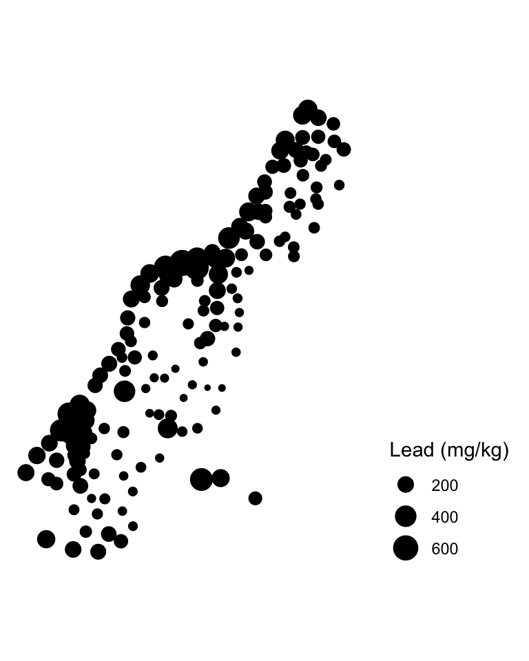

Figure 1: Concentration of lead around the river Meuse.

```r
ggplot(meuse_sf) +
  geom_sf(aes(size = lead)) +
  labs(size = "Lead (mg/kg)") +
  theme(legend.position = "right")
```

# 2 Adding the River

The `meuse` data set is is named after its association with pollution data around the river Meuse. Therefore, it would be logical to include the location of this river in our plot as well.

To achieve this, we need some map data representing the rier Meuse. Our trusty **rnaturalearth** package can assist us once more. However, this time, the necessary data is not included directly in the package. Instead, it must be downloaded using the `ne_download()` function.

Let’s begin by downloading the data.

```r
library(rnaturalearth)

rivers <- ne_download(
  scale = 10,
  type = "rivers_lake_centerlines",
  category = "physical",
  returnclass = "sf"
)
```

`rivers` includes rivers and lakes from around the world, which means that plotting it would result in an excess of unnecessary information. There are two ways to address this, but in either case, we first need to figure out a bounding box that includes the data set’s coordinates, ideally with some extra margin. As you may have begun to notice, there often exists a `st_*()` function for nearly any mapping related issue you might think of. This situation is o exception: `st_bbox()` is the function we can use here.

```r
bbox <- st_bbox(meuse_sf)

bbox
```

```
##     xmin     ymin     xmax     ymax
##  5.72319 50.95661  5.76304 50.99156
```

The first and simplest method for plotting the data involves using the `coord_sf()` function with our `bbox` object to set the limits. While there’s nothing inherently wrong with this approach, and we’ll use it here, it’s worth nothing that a more refined method would be to use `st_crop()`, which directly interacts with our bounding box.

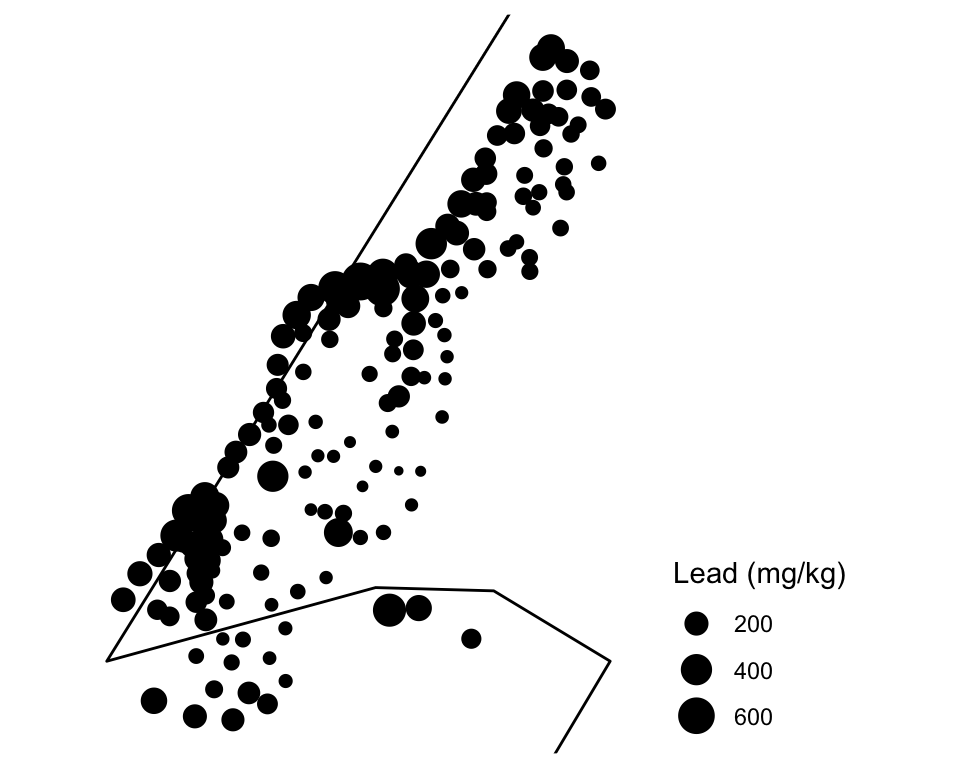

```r
# Alternative solution: river_meuse <- st_crop(rivers, bbox)

ggplot(meuse_sf) +
  geom_sf(aes(size = lead)) +
  geom_sf(data = rivers) +
  coord_sf(
    xlim = c(bbox[["xmin"]], bbox[["xmax"]]),
    ylim = c(bbox[["ymin"]], bbox[["ymax"]])
  ) +
  labs(size = "Lead (mg/kg)") +
  theme(legend.position = "right")
```

The river is represented by a simplified centerline, so we cannot see its width or much of the surrounding landscape. Let’s add a more detailed background.

# 3 Raster Charts

Instead, we will plot a raster map that includes the river and its surrounding area. A raster stores an image as a grid of pixels. The OpenStreetMap background is downloaded by the code below and saved as `meuse-basemap.tif` in your working folder. The following examples read this local copy.

We use **terra** to read the image and **tidyterra** to add it to a ggplot. Install these packages first if needed.

```r
#install.packages(c("terra", "tidyterra"))
```

```r
library(terra)
library(tidyterra)

basemap_url <-
  "https://raw.githubusercontent.com/stat-lu/dataviz/main/worked-examples/notebook/data/meuse-basemap.tif"

download.file(basemap_url, destfile = "meuse-basemap.tif", mode = "wb")

meuse_raster <- rast("meuse-basemap.tif")
```

The background uses Web Mercator coordinates (EPSG:3857). We transform our sample locations from longitude and latitude to this coordinate system, where the coordinate values are expressed in projected metres.

```r
meuse_sf <- st_transform(meuse_sf, crs = 3857)
```

We have now used three coordinate systems to describe the same sampling locations:

| Coordinate system | What the numbers represent |
| --- | --- |
| EPSG:28992 | Dutch national grid coordinates, in metres |
| EPSG:4326 | Longitude and latitude, in degrees |
| EPSG:3857 | Web Mercator coordinates, in projected metres |

We now crop the background to the sample locations’ bounding box with a little extra margin.

```r
bbox_map <- st_bbox(meuse_sf)

xrng <- extendrange(c(bbox_map$xmin, bbox_map$xmax))
yrng <- extendrange(c(bbox_map$ymin, bbox_map$ymax))

meuse_raster <- crop(
  meuse_raster,
  ext(xrng[1], xrng[2], yrng[1], yrng[2])
)
```

`geom_spatraster_rgb()` combines the image’s red, green, and blue channels to draw the background. We save this plot as `meuse_map` so that we can reuse it in the following examples. The caption credits the map’s contributors.

```r
meuse_map <- ggplot() +
  geom_spatraster_rgb(data = meuse_raster) +
  coord_sf(crs = 3857, expand = FALSE) +
  labs(caption = "© OpenStreetMap contributors")
```

Now, we add our sample locations with `geom_sf()`, just as before.

[figure not shown]

Figure 2: Concentration of lead around Meuse.

```r
meuse_map +
  geom_sf(aes(size = lead), data = meuse_sf) +
  labs(size = "Lead (mg/kg)") +
  theme(legend.position = "right")
```

## 3.1 When Coordinates Go Wrong

The map above uses the positions recorded in the original data set. Some appear in water on the background map. The river and floodplain have been reshaped by the [Grensmaas project](https://www.rijkswaterstaat.nl/water/waterbeheer/bescherming-tegen-het-water/maatregelen-om-overstromingen-te-voorkomen/maaswerken/grensmaas), so the older samples and the modern background may not line up everywhere. This does not establish the accuracy of each recorded location. We use the original positions as a reference when comparing two deliberate CRS mistakes.

### 3.1.1 A Very Wrong Coordinate System

First, we convert the coordinates back to longitude and latitude, then make a mistake: we use `st_set_crs(3857)` to label those degree values as Web Mercator coordinates. Unlike `st_transform()`, `st_set_crs()` changes the coordinate system label without converting the values. R warns us about this replacement.

```r
meuse_lonlat <- st_transform(meuse_sf, crs = 4326)
meuse_wrong_crs <- st_set_crs(meuse_lonlat, 3857)
```

```
## Warning: st_crs<- : replacing crs does not reproject data; use st_transform for
## that
```

Numbers around 5.7 and 51 are now interpreted as metres from the Web Mercator origin. The points end up near longitude 0°, latitude 0°, far from the Netherlands. On our local map, they would disappear from view. We use country outlines for an overview that shows both the original and incorrect locations. At this scale, each group of 155 samples appears as a single point.

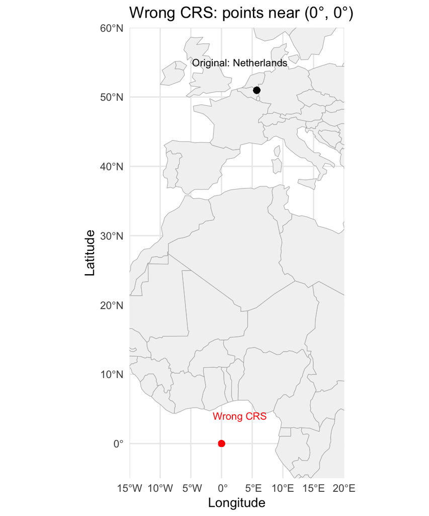

```r
countries <- ne_download(
  scale = 110,
  type = "admin_0_countries",
  category = "cultural",
  returnclass = "sf"
)

ggplot() +
  geom_sf(data = countries, fill = "grey95", colour = "grey70", linewidth = 0.2) +
  geom_sf(data = meuse_sf, size = 2) +
  geom_sf(data = meuse_wrong_crs, colour = "red", size = 2) +
  annotate("text", x = 3, y = 55, label = "Original: Netherlands", size = 3) +
  annotate("text", x = 3, y = 4, label = "Wrong CRS", colour = "red", size = 3) +
  coord_sf(crs = 4326, xlim = c(-15, 20), ylim = c(-5, 60), expand = FALSE) +
  labs(
    title = "Wrong CRS: points near (0°, 0°)",
    x = "Longitude",
    y = "Latitude"
  ) +
  theme_minimal(base_size = 11)
```

### 3.1.2 A Subtle CRS Mistake

A smaller error can be harder to spot. WGS84 (EPSG:4326) and Amersfoort (EPSG:4289) both express longitude and latitude in degrees. However, they use different *datums*, which anchor their coordinates to the Earth in different ways. Amersfoort is the datum underlying the Dutch national grid.

Here, we deliberately mislabel our WGS84 coordinates as Amersfoort coordinates with `st_set_crs(4289)`, then transform them to Web Mercator. The wrong source CRS causes a displacement of about 100 metres at these sampling locations, even though the coordinate values look plausible. R again warns us when we replace the CRS.

```r
meuse_wrong_datum <-
  meuse_lonlat %>%
  st_set_crs(4289) %>%
  st_transform(crs = 3857)
```

```
## Warning: st_crs<- : replacing crs does not reproject data; use st_transform for
## that
```

We use the same background and map extent as before. Hollow black circles mark the original dataset positions; filled red circles mark the positions produced by the wrong CRS. Both use the same point size so that we can focus on the change in position.

[figure not shown]

```r
meuse_map +
  geom_sf(data = meuse_sf, shape = 1, colour = "black", size = 2) +
  geom_sf(data = meuse_wrong_datum, shape = 16, colour = "red", size = 2) +
  labs(
    title = "A subtle CRS mistake: about 100 m displacement",
    subtitle = "Hollow black: original positions; red: wrong datum"
  )
```

Using Amersfoort is not itself a mistake: transforming correctly between coordinate systems preserves the locations. The mistake is assigning the wrong CRS to existing numbers. Here, we should transform `meuse_lonlat` directly to EPSG:3857 with `st_transform()`, keeping its WGS84 source CRS. A convincing-looking map is not enough to establish that its coordinates are correct.

# 4 More Heavy Metal

Let’s make the plot slightly more interesting by including also data on other heavy metals. One approach is to use facets, but for this to effective, our data must be in a long format. This means having one column for the variable names and another for their respective values.

```r
meuse_sf_long <-
  meuse_sf %>%
  pivot_longer(
    cadmium:zinc,
    names_to = "metal",
    values_to = "concentration"
  )
```

We construct our plot as before, faceting on the type of metal.

[figure not shown]

Figure 3: Concentration of different heavy metals around the river Meuse in the Netherlands.

```r
meuse_map +
  geom_sf(
    aes(size = concentration),
    alpha = 0.5,
    data = meuse_sf_long
  ) +
  facet_wrap("metal") +
  labs(size = "Concentration\n(mg/kg)") +
  theme(legend.position = "right")
```

# 5 Geocoding

Purely for instructional purposes, let’s assume we are considering a cleanup of this heavy metal waste and want to assess its potential impact on the nearby ruins of *Kasteel Stein*. We can illustrate this by displaying the ruins on the map.

We don’t have the coordinates of the castle readily available, so we’ll need to determine them through geocoding.

We use tidygeocoder with the [Nominatim](https://nominatim.org/) geocoding service.

Start by generating a `tibble` (or `data.frame`) with the names and addresses that you want to geocode.

```r
library(tidygeocoder)

addresses <- tribble(
  ~name,          ~address,
  "Kasteel Stein", "Kasteel Stein, Netherlands"
)
```

Next, pipe these addresses on to `tidygeocoder::geocode()`.

```r
kasteel_stein <-
  addresses %>%
  tidygeocoder::geocode(
    address,
    method = "osm"
  )

kasteel_stein
```

```
## # A tibble: 1 × 4
##   name          address                      lat  long
##   <chr>         <chr>                      <dbl> <dbl>
## 1 Kasteel Stein Kasteel Stein, Netherlands  51.0  5.76
```

The returned coordinates are longitude and latitude, so we identify them as EPSG:4326 when creating a simple features object. `geom_sf()` will transform them to the map’s coordinate system when plotting.

```r
kasteel_stein_sf <-
  kasteel_stein %>%
  st_as_sf(coords = c("long", "lat"), crs = 4326)
```

To complete our map, we add a red dot and a label for the castle ruins.

[figure not shown]

Figure 4: Concentration of different heavy metals around the river Meuse in the Netherlands.

```r
meuse_map +
  geom_sf(
    aes(size = concentration),
    alpha = 0.5,
    data = meuse_sf_long
  ) +
  geom_sf(
    col = "red",
    data = kasteel_stein_sf
  ) +
  geom_sf_label(
    aes(label = name),
    vjust = -0.5,
    data = kasteel_stein_sf
  ) +
  facet_wrap("metal") +
  labs(size = "Concentration\n(mg/kg)") +
  theme(legend.position = "right")
```

# 6 Source Code

The source code for this document is available at https://github.com/stat-lu/dataviz/blob/main/worked-examples/heavy-metal.Rmd.

[^1]: The `sp` package is a full-featured solution for visualization data and can be used in its own right to create maps in R.